# Homework 03

## Question 1: Build an `explain-to-me` skill

Create a small skill named `explain-to-me` that helps you understand a homework question.

1. Design your `SKILL.md` file so that, when you explicitly ask your agent to use the skill to read a homework question, the agent communicates with you and explains what the question is asking.
2. Keep the skill file short. It should contain a few useful rules, instructions, and a clear statement of your intent. For example, you may ask the agent to explain the goal of the question, clarify what work is required, and point you to an appropriate section of the Week 3 lectures: [Ridge Regression: Stability Through Shrinkage](https://teazrq.github.io/stat432rpy/topics/ridge-regression/ridge-regression.html) or [From a Penalized Objective to a Fitted Ridge Model](https://teazrq.github.io/stat432rpy/topics/ridge-regression/optimization-and-cross-validation.html). The skill should help you understand the question without completing the solution for you.
3. Create the skill yourself or with the help of AI. Save it as `explain-to-me/SKILL.md`. Then ask your AI agent to install the skill using its normal skill-installation method. Test it by explicitly asking the agent to use `explain-to-me` to read and explain Question 2.
4. If the skill does not work well, or if it begins to disturb your usual workflow, ask your agent to remove the installed skill. You may revise and reinstall it if you wish.
5. In all cases, append the complete contents of your developed `explain-to-me/SKILL.md` file at the end of your Homework 3 submission under the heading **`explain-to-me` skill**.

### Solution:

```markdown
---
name: explain-to-me
description: Helps me understand what a homework question is asking without solving it for me.
---

# Explain to Me

When I explicitly ask you to use this skill on a homework question, help me understand the question rather than complete the solution.

## Instructions

1. Explain the main goal of the question in simple language.
2. Break down what the question is asking me to do.
3. Identify the important concepts, formulas, or ideas I should know.
4. Point me to the most relevant Week 3 lecture section:
   - **Ridge Regression: Stability Through Shrinkage**
   - **From a Penalized Objective to a Fitted Ridge Model**
5. Explain any confusing terminology or notation.
6. Do not solve the problem or give the final answer unless I explicitly ask for it afterward.
7. Suggest a good first step, then ask what part remains unclear.

The goal is to help me understand the problem well enough that I can begin solving it myself.
```

## Question 2: Ridge regression with nearly collinear predictors

Let $n=100$. Generate mutually independent standard normal random variables

$$L_i, U_{i1}, U_{i2}, X_{i3}, X_{i4},
\qquad i=1,\ldots,n,$$

and define

$$X_{i1}=L_i+0.04U_{i1},
\qquad
X_{i2}=L_i+0.04U_{i2}.$$

Center and standardize each column of $\mathbf X$ to have mean zero and average squared value one, following the [lecture’s scaling convention](https://teazrq.github.io/stat432rpy/topics/ridge-regression/ridge-regression.html#put-every-covariate-on-a-common-scale).

Continue to use $\mathbf X\in\mathbb R^{n\times p}$ for the standardized matrix and keep it fixed throughout the question, where $p=4$ is the number of predictors. The unpenalized intercept gives $p+1=5$ total fitted coefficients. Let

$$\boldsymbol\beta
=
(1.5,1.5,1,0)^{\mathsf T},
\qquad
\boldsymbol\mu
=
\mathbf X\boldsymbol\beta.$$

Generate a training response and an independent test response at the same predictor values:

$$\begin{aligned}
\mathbf y
&=
\boldsymbol\mu+\boldsymbol\epsilon,\\
\mathbf y^*
&=
\boldsymbol\mu+\boldsymbol\epsilon^*,
\end{aligned}$$

where

$$\boldsymbol\epsilon,
\boldsymbol\epsilon^*
\overset{\mathrm{ind}}{\sim}
\mathcal N_n(\mathbf0,\mathbf I_n).$$

Center the training response as $\widetilde{\mathbf y}=\mathbf y-\bar y\mathbf1_n$. For each $\lambda\in\{0,0.02,0.2\}$, fit the slopes using the lecture’s ridge formula:

$$\widehat{\boldsymbol\beta}_\lambda
=
\left(\mathbf X^{\mathsf T}\mathbf X+n\lambda\mathbf I_p\right)^{-1}
\mathbf X^{\mathsf T}\widetilde{\mathbf y}.$$

The unpenalized intercept is $\widehat\beta_0=\bar y$; add this training mean back when predicting either response. The case $\lambda=0$ is ordinary least squares. Use seed `43231` before generating the design and responses. R and Python use different random-number generators, so their exact numerical results need not agree.

1. Generate $\mathbf X$ once. Report the correlation between its first two columns and its largest and smallest singular values. Use these quantities to explain why the estimator contrast $\widehat\beta_1-\widehat\beta_2$ should be much more variable than $\widehat\beta_1+\widehat\beta_2$.
2. Independently repeat the generation of $\mathbf y$ and $\mathbf y^*$, followed by all three fits, 200 times while keeping $\mathbf X$ fixed. Draw the training and test noise inside each repetition, then reuse that realized pair for all three values of $\lambda$. For each value of $\lambda$, report the empirical mean and standard deviation of

$$\widehat\beta_1,
\quad
\widehat\beta_2,
\quad
\widehat\beta_1+\widehat\beta_2,
\quad
\widehat\beta_1-\widehat\beta_2.$$

Also report the average training MSE and the average test MSE calculated from the independent test response, where

$$\operatorname{MSE}_{\mathrm{test}}
=
\frac{1}{n}
\left\lVert
\mathbf y^*
-
\widehat\beta_0\mathbf1_n
-
\mathbf X\widehat{\boldsymbol\beta}
\right\rVert_2^2.$$

3. Interpret the coefficient estimates and test MSE using bias and variance. Explain why ridge can substantially stabilize the individual coefficients without producing an equally large change in the fitted values.

### Solution:

#### a.

**Show the workflow**

```r
set.seed(43231)

n = 100
p = 4

L = rnorm(n)
U1 = rnorm(n)
U2 = rnorm(n)
X3 = rnorm(n)
X4 = rnorm(n)

X1 = L + 0.04 * U1
X2 = L + 0.04 * U2

X_raw = cbind(X1, X2, X3, X4)

standardize = function(x) {
  z = x - mean(x)
  z / sqrt(mean(z^2))
}

X = apply(X_raw, 2, standardize)

beta = c(1.5, 1.5, 1, 0)
mu = drop(X %*% beta)

cor12 = cor(X[,1], X[,2])
singular_values = svd(X)$d

cor12
```

```
[1] 0.9977057
```

**Show the workflow**

```r
max(singular_values)
```

```
[1] 14.14148
```

**Show the workflow**

```r
min(singular_values)
```

```
[1] 0.4753575
```

The correlation between $X_1$ and $X_2$ is very close to 1, and the smallest singular value is much smaller than the largest. This shows that the predictors are nearly collinear. Because $X_1$ and $X_2$ are almost the same, their sum is well determined, while it is difficult to separate their individual effects. Therefore, $\widehat\beta_1-\widehat\beta_2$ should be much more variable than $\widehat\beta_1+\widehat\beta_2$.

#### b.

**Show the workflow**

```r
B = 200
lambdas = c(0, 0.02, 0.2)

results = data.frame()

for (b in 1:B) {

  epsilon = rnorm(n)
  epsilon_star = rnorm(n)

  y = mu + epsilon
  y_star = mu + epsilon_star

  y_bar = mean(y)
  y_tilde = y - y_bar

  for (lambda in lambdas) {

    beta_hat = solve(
      t(X) %*% X + n * lambda * diag(p),
      t(X) %*% y_tilde
    )

    y_hat = y_bar + drop(X %*% beta_hat)

    results = rbind(
      results,
      data.frame(
        lambda = lambda,
        beta1 = beta_hat[1],
        beta2 = beta_hat[2],
        beta_sum = beta_hat[1] + beta_hat[2],
        beta_diff = beta_hat[1] - beta_hat[2],
        train_mse = mean((y - y_hat)^2),
        test_mse = mean((y_star - y_hat)^2)
      )
    )
  }
}

coef_summary = aggregate(
  cbind(beta1, beta2, beta_sum, beta_diff) ~ lambda,
  data = results,
  FUN = function(x) c(mean = mean(x), sd = sd(x))
)

coef_summary
```

```
  lambda beta1.mean   beta1.sd beta2.mean   beta2.sd beta_sum.mean beta_sum.sd
1   0.00 1.49558941 1.54394848 1.50976489 1.54858847    3.00535430  0.09510778
2   0.02 1.48699449 0.16151331 1.48917648 0.16591120    2.97617097  0.09416526
3   0.20 1.36790821 0.04570277 1.36869328 0.04733702    2.73660149  0.08646679
  beta_diff.mean beta_diff.sd
1   -0.014175478  3.091077615
2   -0.002181997  0.313622468
3   -0.000785071  0.034388477
```

**Show the workflow**

```r
mse_summary = aggregate(
  cbind(train_mse, test_mse) ~ lambda,
  data = results,
  FUN = mean
)

mse_summary
```

```
  lambda train_mse test_mse
1   0.00 0.9647563 1.062452
2   0.02 0.9746809 1.049262
3   0.20 1.0767603 1.133484
```

For $\lambda=0$, the individual estimates $\widehat\beta_1$ and $\widehat\beta_2$ have relatively large variability, especially their difference. As $\lambda$ increases, ridge greatly reduces this variability. The sum stays much more stable because the combined effect of the two highly correlated predictors is easier to estimate. OLS has the lowest training MSE, while ridge may have a lower test MSE because it trades some bias for lower variance.

#### c.

OLS has little bias, but the near collinearity between $X_1$ and $X_2$ causes high variance in their individual coefficient estimates. Ridge shrinks the coefficients, which introduces some bias but greatly reduces their variance. The fitted values do not change nearly as much because $X_1 \approx X_2$, so $X_1\widehat\beta_1+X_2\widehat\beta_2$ is approximately $X_1(\widehat\beta_1+\widehat\beta_2)$.

Therefore, prediction depends mainly on the sum of the two coefficients rather than how the effect is split between them. Ridge can strongly stabilize the individual coefficients while only slightly changing the fitted values. If the reduction in variance is larger than the added bias, ridge can also reduce test MSE.

## Question 3: What does ridge regression shrink?

Let $\mathbf X\in\mathbb R^{n\times p}$ be a centered predictor matrix, and let $\widetilde{\mathbf y}\in\mathbb R^n$ be the centered response. Use the supplied predictor scales for this algebraic question; the columns need not have unit variance. Here $p$ counts predictors, $\boldsymbol\beta\in\mathbb R^p$ contains their slopes, and $p+1$ counts all fitted coefficients, including the separately fitted, unpenalized intercept. Ridge regression minimizes

$$L_\lambda(\boldsymbol\beta)
=
\frac{1}{2n}
\left\lVert
\widetilde{\mathbf y}-\mathbf X\boldsymbol\beta
\right\rVert_2^2
+
\frac{\lambda}{2}
\lVert\boldsymbol\beta\rVert_2^2.$$

1. Derive the ridge normal equation

$$\left(
\mathbf X^{\mathsf T}\mathbf X
+n\lambda\mathbf I_p
\right)
\widehat{\boldsymbol\beta}_\lambda
=
\mathbf X^{\mathsf T}\widetilde{\mathbf y}.$$

Explain why it has a unique solution whenever $\lambda>0$, even if $\mathbf X$ is rank deficient or $p>n$.

2. Let

$$\mathbf X
=
\mathbf U_r\mathbf D_r\mathbf V_r^{\mathsf T}$$

be a compact singular value decomposition, where $r=\operatorname{rank}(\mathbf X)$, $\mathbf U_r\in\mathbb R^{n\times r}$, $\mathbf D_r\in\mathbb R^{r\times r}$, and $\mathbf V_r\in\mathbb R^{p\times r}$. Show that ridge multiplies the fitted response component in the $j$th left singular-vector direction, for $j=1,\ldots,r$, by

$$\rho_j(\lambda)
=
\frac{d_j^2}{d_j^2+n\lambda}.$$

Suppose $n=100$, $\lambda=0.01$, and the nonzero singular values are

$$d_1=10,
\qquad
d_2=2,
\qquad
d_3=0.2.$$

Calculate the three shrinkage factors and the total effective degrees of freedom, including the unpenalized intercept:

$$\operatorname{df}_{\mathrm{eff}}(\lambda)
=
1+\sum_{j=1}^3\rho_j(\lambda).$$

3. Which direction receives the strongest shrinkage? Explain why shrinking this direction can reduce prediction variance. Under what circumstance could the same shrinkage produce substantial prediction bias?

### Solution:

#### (a)

The ridge objective is

$$L_\lambda(\boldsymbol\beta)
=
\frac{1}{2n}
\|\widetilde{\mathbf y}-\mathbf X\boldsymbol\beta\|_2^2
+
\frac{\lambda}{2}\|\boldsymbol\beta\|_2^2.$$

Taking the gradient with respect to $\boldsymbol\beta$ gives

$$\nabla L_\lambda(\boldsymbol\beta)
=
-\frac{1}{n}\mathbf X^{\mathsf T}
(\widetilde{\mathbf y}-\mathbf X\boldsymbol\beta)
+
\lambda\boldsymbol\beta.$$

Setting the gradient equal to zero,

$$-\frac{1}{n}\mathbf X^{\mathsf T}
(\widetilde{\mathbf y}-\mathbf X\widehat{\boldsymbol\beta}_\lambda)
+
\lambda\widehat{\boldsymbol\beta}_\lambda
=0.$$

Multiplying by $n$ and rearranging gives

$$\left(
\mathbf X^{\mathsf T}\mathbf X
+n\lambda\mathbf I_p
\right)
\widehat{\boldsymbol\beta}_\lambda
=
\mathbf X^{\mathsf T}\widetilde{\mathbf y}.$$

For $\lambda>0$, the matrix $\mathbf X^{\mathsf T}\mathbf X+n\lambda\mathbf I_p$ is positive definite because for any nonzero vector $\mathbf a$,

$$\mathbf a^{\mathsf T}
(\mathbf X^{\mathsf T}\mathbf X+n\lambda\mathbf I_p)
\mathbf a
=
\|\mathbf X\mathbf a\|_2^2
+n\lambda\|\mathbf a\|_2^2
>0.$$

Therefore, the matrix is invertible and ridge has a unique solution even if $\mathbf X$ is rank deficient or $p>n$.

#### (b)

Using the compact SVD $\mathbf X=\mathbf U_r\mathbf D_r\mathbf V_r^{\mathsf T}$, the ridge estimator can be written as

$$\widehat{\boldsymbol\beta}_\lambda
=
\mathbf V_r
(\mathbf D_r^2+n\lambda\mathbf I_r)^{-1}
\mathbf D_r
\mathbf U_r^{\mathsf T}\widetilde{\mathbf y}.$$

Therefore,

$$\mathbf X\widehat{\boldsymbol\beta}_\lambda
=
\mathbf U_r
\operatorname{diag}
\left(
\frac{d_1^2}{d_1^2+n\lambda},
\ldots,
\frac{d_r^2}{d_r^2+n\lambda}
\right)
\mathbf U_r^{\mathsf T}\widetilde{\mathbf y}.$$

Thus the shrinkage factor in direction $j$ is

$$\rho_j(\lambda)
=
\frac{d_j^2}{d_j^2+n\lambda}.$$

Here $n\lambda=100(0.01)=1$, so

$$\rho_1
=
\frac{10^2}{10^2+1}
=
\frac{100}{101}
\approx 0.9901,$$

$$\rho_2
=
\frac{2^2}{2^2+1}
=
\frac{4}{5}
=
0.8000,$$

and

$$\rho_3
=
\frac{0.2^2}{0.2^2+1}
=
\frac{0.04}{1.04}
\approx 0.0385.$$

Including the unpenalized intercept,

$$\operatorname{df}_{\mathrm{eff}}
=
1+0.9901+0.8000+0.0385
\approx 2.8286.$$

#### (c)

The third direction, with $d_3=0.2$, receives the strongest shrinkage because it has the smallest singular value and therefore the smallest shrinkage factor, $\rho_3\approx0.0385$. A small singular value represents a direction where the design contains little information. OLS can greatly amplify response noise in this direction, causing high prediction variance. Ridge shrinks this weak direction and reduces that noise amplification. However, if the true mean contains an important signal in this weak singular-vector direction, strong shrinkage would also remove much of that real signal. In that case, ridge could introduce substantial prediction bias.

## Question 4: Ridge regression and optimization

Let $\mathbf X\in\mathbb R^{n\times p}$ be a centered predictor matrix with $p=2$. Its columns need not have unit variance in this question. The intercept is fitted separately and is not penalized. Suppose the two eigenvalues of

$$\mathbf A_0
=
\frac{1}{n}\mathbf X^{\mathsf T}\mathbf X$$

are $9$ and $0.01$. Ridge regression with $\lambda=0.09$ has curvature matrix

$$\mathbf A_\lambda
=
\frac{1}{n}\mathbf X^{\mathsf T}\mathbf X
+
\lambda\mathbf I_p.$$

1. Calculate the condition numbers of $\mathbf A_0$ and $\mathbf A_\lambda$. Explain what the change says about the geometry of the ridge objective.
2. Gradient descent uses

$$\boldsymbol\beta^{(k+1)}
=
\boldsymbol\beta^{(k)}
-
\eta\nabla L_\lambda\!\left(\boldsymbol\beta^{(k)}\right).$$

Let $\widehat{\boldsymbol\beta}_\lambda$ be the ridge minimizer and define the optimization error

$$\mathbf e^{(k)}
=
\boldsymbol\beta^{(k)}
-
\widehat{\boldsymbol\beta}_\lambda.$$

Show that the component of $\mathbf e^{(k)}$ in an eigendirection with unpenalized eigenvalue $a$ is multiplied at each step by

$$1-\eta(a+\lambda).$$

Let $M=9.09$, the largest eigenvalue of $\mathbf A_\lambda$. Find the interval of step sizes that contracts every eigendirection. Then compare these two choices:

- For $\eta=1/M$, calculate the two contraction factors and explain which direction converges faster.
- For $\eta=2.1/M$, determine whether the method converges. Assume the initial error has a nonzero component in the eigendirection corresponding to $M$.
3. Increasing $\lambda$ generally improves the condition number. Explain why choosing $\lambda$ to make gradient descent converge as quickly as possible is not a valid statistical tuning rule.

### Solution:

#### (a)

The eigenvalues of $\mathbf A_0$ are $9$ and $0.01$, so

$$\kappa(\mathbf A_0)
=
\frac{9}{0.01}
=
900.$$

Ridge adds $\lambda=0.09$ to each eigenvalue, giving eigenvalues $9.09$ and $0.10$. Therefore,

$$\kappa(\mathbf A_\lambda)
=
\frac{9.09}{0.10}
=
90.9.$$

The condition number decreases from $900$ to $90.9$. This means the ridge objective has a less narrow and elongated shape. Its curvature is more balanced across directions, which makes the optimization problem better conditioned.

#### (b)

For ridge,

$$\nabla L_\lambda(\boldsymbol\beta)
=
\mathbf A_\lambda\boldsymbol\beta-\mathbf b,$$

where $\mathbf b=\mathbf X^{\mathsf T}\widetilde{\mathbf y}/n$. Since $\widehat{\boldsymbol\beta}_\lambda$ satisfies $\mathbf A_\lambda\widehat{\boldsymbol\beta}_\lambda=\mathbf b$,

$$\mathbf e^{(k+1)}
=
(\mathbf I-\eta\mathbf A_\lambda)\mathbf e^{(k)}.$$

Therefore, in an eigendirection with unpenalized eigenvalue $a$, the error is multiplied by

$$1-\eta(a+\lambda).$$

For contraction in every direction, we need

$$|1-\eta(a+\lambda)|<1.$$

Using the largest eigenvalue $M=9.09$,

$$0<\eta<\frac{2}{M}
=
\frac{2}{9.09}
\approx0.2200.$$

For $\eta=1/M$, the contraction factor for the $9.09$ direction is

$$1-\frac{9.09}{9.09}=0,$$

while the factor for the $0.10$ direction is

$$1-\frac{0.10}{9.09}
\approx0.9890.$$

Thus, the high-curvature direction converges immediately, while the low-curvature direction converges much more slowly.

For $\eta=2.1/M$, the contraction factor in the largest-eigenvalue direction is

$$1-\frac{2.1}{9.09}(9.09)
=
-1.1.$$

Since $|-1.1|>1$, that error component grows rather than contracts. Because the initial error has a nonzero component in this direction, gradient descent does not converge.

#### (c)

Increasing $\lambda$ improves the condition number and can make gradient descent converge faster, but $\lambda$ is a statistical tuning parameter, not just an optimization parameter. Changing $\lambda$ changes the fitted model by increasing coefficient shrinkage.

A very large $\lambda$ may make optimization easy but can introduce substantial bias and hurt prediction. Therefore, $\lambda$ should be chosen based on predictive performance, such as cross-validation, rather than choosing the value that makes gradient descent converge fastest.

## Question 5: Selecting the ridge penalty for real-estate prediction

The supplied `data/realestate.csv` contains 414 real-estate transactions from Sindian District, New Taipei City, Taiwan. The quantitative response `price` is the unit house price. The six predictors are the transaction date, house age, distance to the nearest mass rapid transit station, number of nearby convenience stores, latitude, and longitude. Treat all six predictors as quantitative in this question. The column `row_id` identifies an observation and must not be used as a predictor.

The file `data/realestate-split-folds.csv` assigns 332 observations to the training set and 82 observations to the final test set. It also gives ten fold labels for the training observations. Match the two files using `row_id` and do not use the test responses while selecting a model.

Use the penalty grid

$$\Lambda
=
\{0\}
\mathbin{\cup}
\left\{
10^{-4+0.05l}:l=0,\ldots,120
\right\}.$$

For every fit, center and standardize each predictor using only the observations available to that fit, with the variance divided by the number of fitting observations. Center the response and leave the intercept unpenalized.

1. Perform ten-fold cross-validation over $\Lambda$ using the supplied training folds. Estimate the predictor means and scales separately within each set of nine training folds. For each $\lambda$, calculate the mean validation MSE and $\operatorname{SE}(\lambda)$, the sample standard deviation of the ten fold errors divided by $\sqrt{10}$. Use this SE for the conventional one-standard-error heuristic. Plot the mean validation MSE and identify $\lambda_{\min}$. Choose $\lambda_{\mathrm{1se}}$ as the largest candidate in $\Lambda$, including OLS, satisfying

$$\overline{\operatorname{MSE}}(\lambda)
\leq
\overline{\operatorname{MSE}}(\lambda_{\min})
+
\operatorname{SE}(\lambda_{\min}).$$

2. Use all $n=332$ training observations to calculate the [lecture’s GCV criterion](https://teazrq.github.io/stat432rpy/topics/ridge-regression/optimization-and-cross-validation.html#loocv-and-gcv) for each $\lambda\in\Lambda$:

$$\operatorname{GCV}(\lambda)
=
\frac{
\operatorname{MSE}_{\mathrm{train}}(\lambda)
}{
\left\{
1-\operatorname{df}_{\mathrm{eff}}(\lambda)/n
\right\}^2
}.$$

Here $\operatorname{MSE}_{\mathrm{train}}$ is the training MSE, and $\operatorname{df}_{\mathrm{eff}}$ includes the unpenalized intercept, as in Question 3. Estimate means and scales once from all training observations and keep them fixed for this calculation. Plot the GCV curve and identify $\lambda_{\mathrm{GCV}}$.

3. Fix all three choices before examining the test responses. Refit OLS and ridge at $\lambda_{\min}$, $\lambda_{\mathrm{1se}}$, and $\lambda_{\mathrm{GCV}}$ using all training observations. Report each model’s training MSE, test MSE, and effective degrees of freedom. Interpret the differences and explain why the model with the smallest observed test MSE must not be selected after viewing this table.

**TipStarter workflow**

After matching the two files by `row_id`, use this order:

```
for each validation fold:
    estimate predictor means and scales from the other nine folds
    for each lambda:
        fit on those nine folds and record validation MSE
summarize the ten fold errors and fix lambda_min and lambda_1se
compute GCV using all training observations and fix lambda_GCV
only then refit the four reported models and evaluate the test responses
```

### Solution:

#### (a)

**Show the workflow**

```r
realestate = read.csv("data/realestate.csv", check.names = FALSE)
split_folds = read.csv("data/realestate-split-folds.csv", check.names = FALSE)

realestate = merge(
  realestate, split_folds,
  by = "row_id", all.x = TRUE, sort = FALSE
)
realestate = realestate[order(realestate$row_id), ]

feature_names = setdiff(
  names(realestate),
  c("row_id", "price", "split", "cv_fold")
)

lambda_grid = c(0, 10^(-4 + 0.05 * (0:120)))

train_rows = realestate$split == "train"

X_train_raw = as.matrix(realestate[train_rows, feature_names])
y_train_raw = realestate$price[train_rows]
fold_id = realestate$cv_fold[train_rows]

standardize_xy = function(X_raw, y) {
  x_bar = colMeans(X_raw)
  X_centered = sweep(X_raw, 2, x_bar, "-")
  s = sqrt(colMeans(X_centered^2))

  list(
    X = sweep(X_centered, 2, s, "/"),
    y_centered = y - mean(y),
    x_bar = x_bar,
    s = s,
    y_bar = mean(y)
  )
}

ridge_closed = function(X, y_centered, lambda) {
  p = ncol(X)
  solve(
    crossprod(X) / nrow(X) + lambda * diag(p),
    crossprod(X, y_centered) / nrow(X)
  )
}

fold_levels = sort(unique(fold_id))
fold_mse = matrix(
  NA_real_,
  nrow = length(fold_levels),
  ncol = length(lambda_grid)
)

for (k in seq_along(fold_levels)) {

  fold = fold_levels[k]
  validation = fold_id == fold

  X_fold_raw = X_train_raw[!validation, , drop = FALSE]
  y_fold = y_train_raw[!validation]

  prepared = standardize_xy(X_fold_raw, y_fold)

  X_validation = sweep(
    X_train_raw[validation, , drop = FALSE],
    2, prepared$x_bar, "-"
  )
  X_validation = sweep(X_validation, 2, prepared$s, "/")

  for (l in seq_along(lambda_grid)) {

    beta_hat = ridge_closed(
      prepared$X,
      prepared$y_centered,
      lambda_grid[l]
    )

    y_hat = prepared$y_bar + drop(X_validation %*% beta_hat)

    fold_mse[k, l] = mean(
      (y_train_raw[validation] - y_hat)^2
    )
  }
}

mean_cv_mse = colMeans(fold_mse)
se_cv_mse = apply(fold_mse, 2, sd) / sqrt(10)

minimum_index = which.min(mean_cv_mse)
lambda_min = lambda_grid[minimum_index]

one_se_threshold =
  mean_cv_mse[minimum_index] + se_cv_mse[minimum_index]

eligible = which(mean_cv_mse <= one_se_threshold + 1e-12)
one_se_index = eligible[which.max(lambda_grid[eligible])]
lambda_1se = lambda_grid[one_se_index]

data.frame(
  lambda_min = lambda_min,
  lambda_1se = lambda_1se,
  minimum_CV_MSE = mean_cv_mse[minimum_index],
  one_SE_threshold = one_se_threshold
)
```

```
  lambda_min lambda_1se minimum_CV_MSE one_SE_threshold
1 0.01995262   1.584893       82.97765         102.2076
```

**Show the workflow**

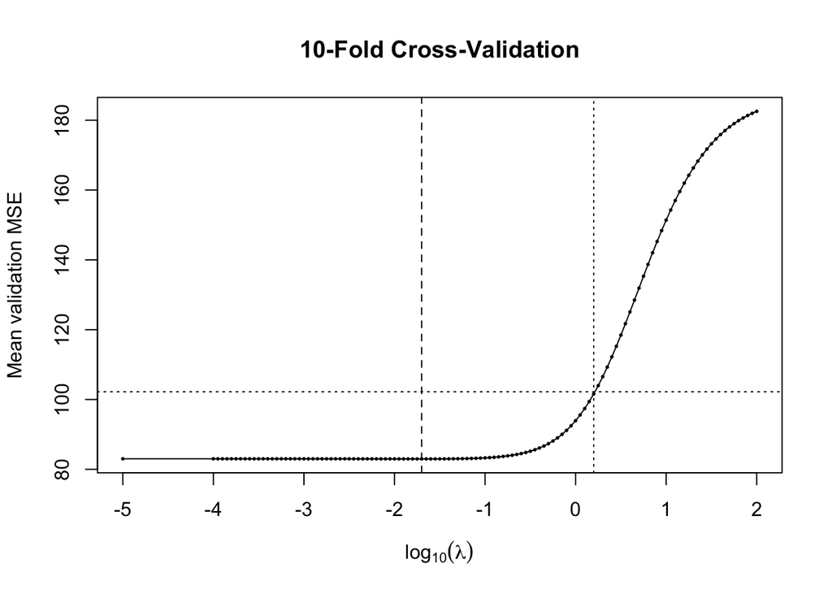

```r
plot_x = ifelse(lambda_grid == 0, -5, log10(lambda_grid))

plot(
  plot_x, mean_cv_mse,
  type = "l",
  xlab = expression(log[10](lambda)),
  ylab = "Mean validation MSE",
  main = "10-Fold Cross-Validation"
)

points(plot_x, mean_cv_mse, pch = 16, cex = 0.4)
abline(v = plot_x[minimum_index], lty = 2)
abline(v = plot_x[one_se_index], lty = 3)
abline(h = one_se_threshold, lty = 3)
```

The cross-validation minimum occurs at $\lambda_{\min} =$ 0.01995. Using the one-standard-error rule, the largest eligible penalty is $\lambda_{\mathrm{1se}} =$ 1.585. The one-SE choice uses stronger shrinkage while still remaining within one standard error of the minimum cross-validation error.

#### (b)

**Show the workflow**

```r
prepared_all = standardize_xy(X_train_raw, y_train_raw)

X_train = prepared_all$X
y_centered = prepared_all$y_centered
n_train = nrow(X_train)

singular_values = svd(X_train, nu = 0, nv = 0)$d

ridge_path = data.frame(
  lambda = lambda_grid,
  train_mse = NA_real_,
  df_eff = NA_real_,
  gcv = NA_real_
)

for (l in seq_along(lambda_grid)) {

  lambda = lambda_grid[l]

  beta_hat = ridge_closed(
    X_train,
    y_centered,
    lambda
  )

  y_hat =
    prepared_all$y_bar + drop(X_train %*% beta_hat)

  train_mse = mean((y_train_raw - y_hat)^2)

  df_eff =
    1 + sum(
      singular_values^2 /
        (singular_values^2 + n_train * lambda)
    )

  gcv =
    train_mse /
    (1 - df_eff / n_train)^2

  ridge_path$train_mse[l] = train_mse
  ridge_path$df_eff[l] = df_eff
  ridge_path$gcv[l] = gcv
}

gcv_index = which.min(ridge_path$gcv)
lambda_gcv = lambda_grid[gcv_index]

data.frame(
  lambda_GCV = lambda_gcv,
  minimum_GCV = ridge_path$gcv[gcv_index]
)
```

```
  lambda_GCV minimum_GCV
1 0.02818383    83.50191
```

**Show the workflow**

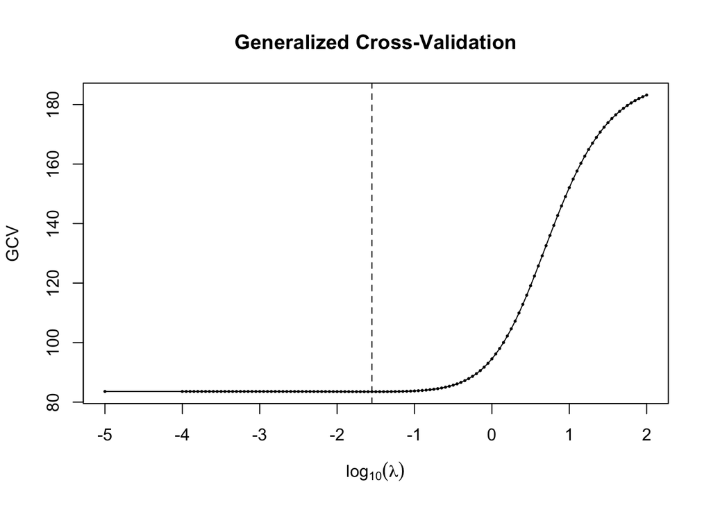

```r
plot(
  plot_x, ridge_path$gcv,
  type = "l",
  xlab = expression(log[10](lambda)),
  ylab = "GCV",
  main = "Generalized Cross-Validation"
)

points(plot_x, ridge_path$gcv, pch = 16, cex = 0.4)
abline(v = plot_x[gcv_index], lty = 2)
```

Using all 332 training observations, the GCV criterion is minimized at $\lambda_{\mathrm{GCV}} =$ 0.02818. GCV can select a different value from ten-fold cross-validation because it uses the full-training smoother and adjusts its training error using effective degrees of freedom.

#### (c)

**Show the workflow**

```r
fit_ridge_model = function(X_raw, y, lambda) {

  prepared = standardize_xy(X_raw, y)

  beta_hat = ridge_closed(
    prepared$X,
    prepared$y_centered,
    lambda
  )

  beta_hat_raw = beta_hat / prepared$s

  raw_intercept =
    prepared$y_bar -
    sum(prepared$x_bar * beta_hat_raw)

  singular_values =
    svd(prepared$X, nu = 0, nv = 0)$d

  df_eff =
    1 + sum(
      singular_values^2 /
        (singular_values^2 + nrow(X_raw) * lambda)
    )

  list(
    beta_hat_raw = beta_hat_raw,
    raw_intercept = raw_intercept,
    df_eff = df_eff
  )
}

predict_ridge = function(fit, X_new_raw) {
  drop(
    fit$raw_intercept +
      X_new_raw %*% fit$beta_hat_raw
  )
}

test_rows = realestate$split == "test"

X_test_raw =
  as.matrix(realestate[test_rows, feature_names])

y_test_raw =
  realestate$price[test_rows]

model_names =
  c("OLS", "CV minimum", "One-SE", "GCV")

lambda_choices =
  c(0, lambda_min, lambda_1se, lambda_gcv)

results = data.frame()

for (j in seq_along(lambda_choices)) {

  fit = fit_ridge_model(
    X_train_raw,
    y_train_raw,
    lambda_choices[j]
  )

  train_hat = predict_ridge(fit, X_train_raw)
  test_hat = predict_ridge(fit, X_test_raw)

  results = rbind(
    results,
    data.frame(
      Model = model_names[j],
      Lambda = lambda_choices[j],
      Effective_df = fit$df_eff,
      Training_MSE =
        mean((y_train_raw - train_hat)^2),
      Test_MSE =
        mean((y_test_raw - test_hat)^2)
    )
  )
}

knitr::kable(
  results,
  digits = c(0, 4, 2, 2, 2),
  caption = "Training and test mean squared error"
)
```

Training and test mean squared error

| Model | Lambda | Effective_df | Training_MSE | Test_MSE |
| --- | --- | --- | --- | --- |
| OLS | 0.0000 | 7.00 | 80.09 | 66.32 |
| CV minimum | 0.0200 | 6.77 | 80.14 | 66.00 |
| One-SE | 1.5849 | 3.03 | 100.37 | 81.20 |
| GCV | 0.0282 | 6.69 | 80.17 | 65.90 |

**Show the workflow**

```r
best_test_model =
  results$Model[which.min(results$Test_MSE)]
```

OLS has the greatest effective degrees of freedom and should have the smallest training MSE because it directly minimizes the training squared error. Ridge reduces the effective degrees of freedom as the penalty increases, trading some additional bias for lower variance.

In this particular test set, the smallest observed test MSE is produced by the GCV model. However, this result cannot be used to choose a different model after seeing the table. The penalties were already selected using only the training data. Choosing a model based on the final test MSE would turn the test set into another tuning set and would make its error an optimistically biased estimate of future prediction performance.

## Reference

The real-estate data come from I-Cheng Yeh’s [Real Estate Valuation dataset](https://archive.ics.uci.edu/dataset/477/real%2Bestate%2Bvaluation%2Bda) in the UCI Machine Learning Repository. The distributed data retain the original observations and add only the course train-test and fold assignments.